# Proyecto Final

Inma Latorre

11/12/2019

# **Curso de iniciación a R**

## Contenido

1. Recursos sobre expresiones regulares discutidas: RPubs y Riptutorial.
2. Recursos sobre markdown discutidas: Rstudio y r4ds
3. Estudio descriptivo del *dataset* contenido en R ChickWeight.

### 1. Expresiones Regulares

Expresión regular, también conocida como *regex*, *regexp* o expresión racional, es una secuencia de caracteres que forma un patrón de búsqueda, principalmente utilizada para la búsqueda de patrones de cadenas de caracteres u operaciones de sustituciones.

A continuación, compararemos dos páginas de recursos para su aprendizaje que se pueden encontrar en Internet, fijándonos en su contenido, código y estética.

Con ello la **conclusión** será la siguiente: que el nombre de la página (RIP tutorial) es un buen indicativo de la calidad instructiva del mismo. En mi opinión, llamarle tutorial es excederse. Por lo tanto, tras compararlo con los recursos que hay en RPubs, llegamos a la determinación de que este último es mejor para el aprendizaje sobre las *regex*.

#### 1.1 RPubs

[RPubs](http://rpubs.com/ydmarinb/429756) es el primer recurso que vamos a estudiar:

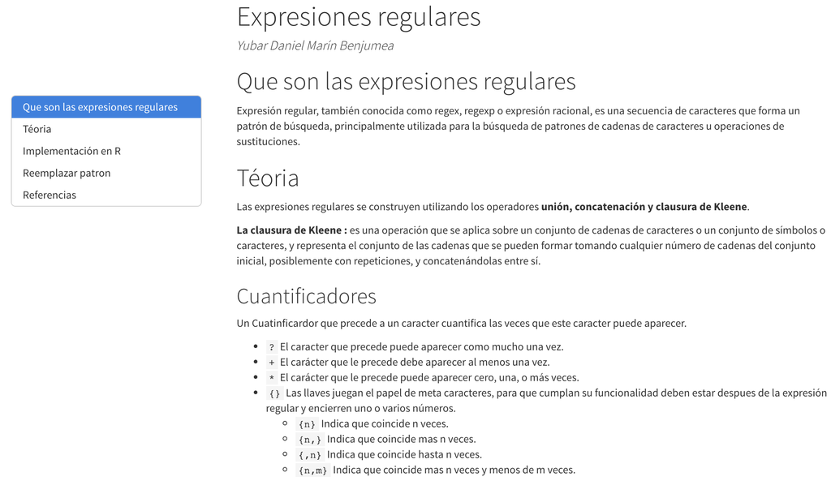

- *Contenido:* Teórico y ejemplificativo. Contiene una estructura lógica, empezando por la teoría básica, para luego adentrarse en la implementación en R con sus debidos ejemplos.
- *Código:* Correctamente ejecutado. Se muestra el código cuando es justificado y relevante, es decir, cuando quiere mostrar como se ha llegado a aquello que trata de enseñar.
- *Estética:* Armoniosa y clara. Con un patrón coherente sin excesivos formatos de texto especiales.

#### 1.2. Riptutorial

[Riptutorial](https://riptutorial.com/es/r/topic/5748/expresiones-regulares--expresiones-regulares-) es el segundo recurso que vamos a estudiar:

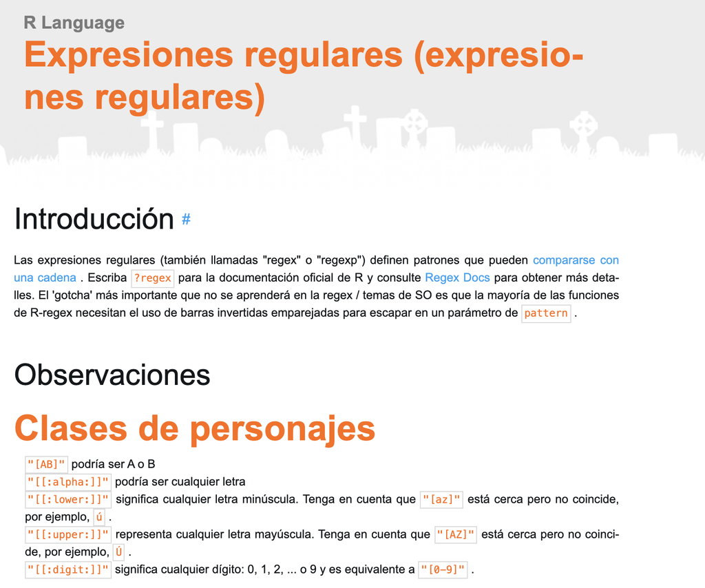

- *Contenido:* Escaso y poco claro. Destaca las cuestiones teóricas básicas, sin poner ejemplos de ello. Para un usuario que se está iniciando con este lenguaje resulta complicado su comprendimiento y aplicación práctica.
- *Código:* Limitado. Más allá de enlace a otras páginas web y cambio de color sin un patrón o lógica claros, no existe un código formulado de cierta complejidad.
- *Estética:* Estresante. No cumple la normativa ortotipográfica ya que, tiene un color destacado y un tamaño de fuente mayor los subtítulos dentro de las secciones.

### 2. R Markdown

R Markdown es un formato que permite una fácil creación de documentos, presentaciones dinámicas y informes de R. Markdown es un formato de sintaxis simple para crear documentos en HTML, PDF, y Word.

A continuación, siguiendo con el mismo patrón que en el punto anterior, compararemos dos páginas de recursos para su aprendizaje que se pueden encontrar en Internet por su contenido, código y estética.

En base a dichos puntos, concluiremos cuál es mejor y cuál peor para formarse y crear buenos documentos en formato R Markdown. Dicha **conclusión** es que RStudio es muy buen recurso para, de un vistazo, poder saber lo básico que alcanza un documento RMarkdown. Sin embargo, si lo que se quiere es un conocimiento más profundo, es mejor recurrir a r4ds.

#### 2.1. Rstudio

[Rstudio.com](https://rstudio.com/wp-content/uploads/2015/03/rmarkdown-spanish.pdf) es el primer recurso que vamos a estudiar:

[figure not shown]

- *Contenido:* Conciso y claro. Explicando todos los pasos inciales para crear un documento RMarkdown, indicando cómo cambiar la estética del texto más básica.
- *Código:* Sin gran contenido de código de R, más allá de la parte de texto. Por tanto, no hay lugar a errores en ejecución del mismo.
- *Estética:* Coherente. Estéticamente agradable, deja claro cómo se ve en un documento RMarkdown el la teoría descrita.

#### 2.2. R4ds

[r4ds](https://es.r4ds.hadley.nz/r-markdown.html) es el segundo recurso que vamos a estudiar:

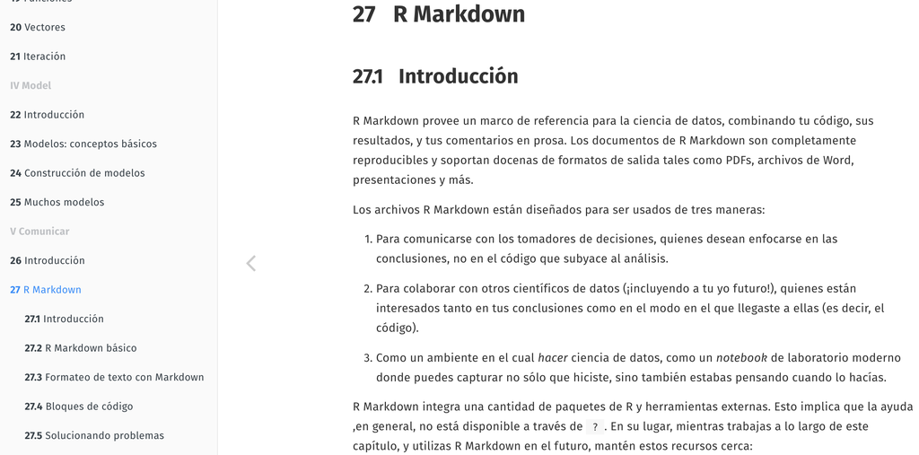

- *Contenido*: Estructurado y extenso. Para un aprendizaje en mayor profundidad de su uso. Buen material para aprneder cosas más allá de un documento básico.
- *Código*: Muy bueno. Muestra a propósito código en la parte instructora, pero no lo hace en las partes que no es necesario.
- *Estética*: Docente. Siguiendo la estructura de un libro académico, no se excede en florituras innecesarias.

### 3. ChickWeight: estudio básico

A continuación, trabajaremos el conjunto de datos **ChickWeight** que tiene un total de 548 filas y 4 columnas que representa la progresión del peso de varios pollitos. Casa pollito es alimentado con una dieta específica, de las cuales hay cuatro tipos.

Las diferentes variables recogidas en dicho *dataset* son las siguientes:

```
## [1] "weight" "Time"   "Chick"  "Diet"
```

Donde:

1. *Weight:* Es el peso del pollito, en gramos
2. *Time:* Edad, en días, del pollito
3. *Chick:* Pollito, ordenado numéricamente como factor
4. *Diet:* Tipo de dieta que ha llevado el pollito, representado 1-4 como factor

Veamos, en primer lugar, algunos estadísticos descriptivos básicos del peso de los pollitos:

- Mediana:

```
## [1] 103
```

- Desviación:

```
## [1] 71.07196
```

- Media:

```
## [1] 121.8183
```

- Coeficiente de variación de Pearson:

```
## [1] 0.5834258
```

Nuestra muestra es, por tanto, dispersa, dado que el coeficiente de variación el de Pearson está más cerca de 1 que de 0.

En segundo lugar, estudiaremos el cambio del peso de los pollitos con el paso de los días:

Evolución del peso de los pollitos los primeros días de vida

| Días | Peso_Medio |
| --- | --- |
| 0 | 41,06 |
| 2 | 49,22 |
| 4 | 59,96 |
| 6 | 74,31 |
| 8 | 91,24 |
| 10 | 107,84 |
| 12 | 129,24 |
| 14 | 143,81 |
| 16 | 168,09 |
| 18 | 190,19 |
| 20 | 209,72 |
| 21 | 218,69 |

La media de peso el día del nacimiento de los pollitos fue 41.06 gramos. La media de peso el último día que se tomaron datos, el 21, fue de 218.69 gramos. Es decir, en el periodo de tiempo transcurrido, de media multplican su peso más de 5 veces.

Por último, estudiaremos la evolución del peso con el transcurso de los días en cada una de las dietas para poder contrastar las siguientes hipótesis:

- *H<sub>0</sub>:* Todas las dietas tienen el mismo efecto en el peso de los pollitos
- *H<sub>1</sub>:* Las dietas tienen diferentes efectos en el peso de los pollitos

Para un mejor entendimiento y visualización de ello, trabajamos con los datos modificados con la librería `reshape2` y los plasmamos en una tabla y un gráfico por facetas:

Efecto en el peso en los pollitos según dieta y tiempo

| Dieta | Día_0 | Día_2 | Día_4 | Día_6 | Día_8 | Día_10 | Día_12 | Día_14 | Día_16 | Día_18 | Día_20 | Día_21 |
| --- | --- | --- | --- | --- | --- | --- | --- | --- | --- | --- | --- | --- |
| 1 | 41,4 | 47,25 | 56,47 | 66,79 | 79,68 | 93,05 | 108,53 | 123,39 | 144,65 | 158,94 | 170,41 | 177,75 |
| 2 | 40,7 | 49,40 | 59,80 | 75,40 | 91,70 | 108,50 | 131,30 | 141,90 | 164,70 | 187,70 | 205,60 | 214,70 |
| 3 | 40,8 | 50,40 | 62,20 | 77,90 | 98,40 | 117,10 | 144,40 | 164,50 | 197,40 | 233,10 | 258,90 | 270,30 |
| 4 | 41,0 | 51,80 | 64,50 | 83,90 | 105,60 | 126,00 | 151,40 | 161,80 | 182,00 | 202,90 | 233,89 | 238,56 |

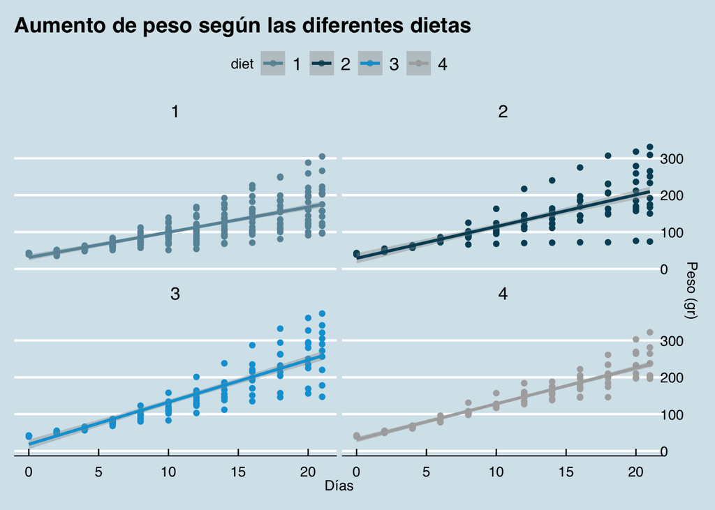

Tanto la tabla como la gráfica de puntos por facetas muestra que los pollitos engordan con el paso del tiempo. Aparentemente la desviación estándar de pesos también se incrementan.

Observamos que la Dieta 3 es la más pesada, provocando que los pollitos que siguen dicha dieta tengan una tendencia mayor a engordar. Si bien, no dista mucho del componente calórico que pueda tener la Dieta 4 que muchos días provoca que el peso medio de los pollitos sea mayor que la Dieta 3.

La Dieta 1, sin embargo, es la más ligera, cuya media de peso más alta (el útlimo día de datos, es decir, el día 21) es alcanzada por la Dieta 3 y 4 ya en el día 16.